# Prosper Loan Data Exploration

## by Demagh Mohamed El Amine

## Investigation Overview

In this report, I wanted to investigate the features that could best predict the outcome of a loan (completed or charged-off). I explored the 5 main variables of a Prosper loan: loan amount, listing category, loan term, lender yield, and Prosper rating.

## Dataset Overview

The dataset contained information about 113937 loans and 81 variables. It included two periods of the company: a pre-2009 period before the enactment of the laws for online lending and a post-2009 period where Prosper had changed its business model to comply with the new laws. I only looked at the loans that originated after 2009 because I wanted to capture the latest trends in the data. My subset consisted of 84997 loans that originated from 6 August 2009 to 27 March 2014.

## Loan Status

Of the loans with an outcome, there were 78.65% completed loans and 21.35% charged-off loans. This means that over 5 years, 1/5 of the loans were charged off.

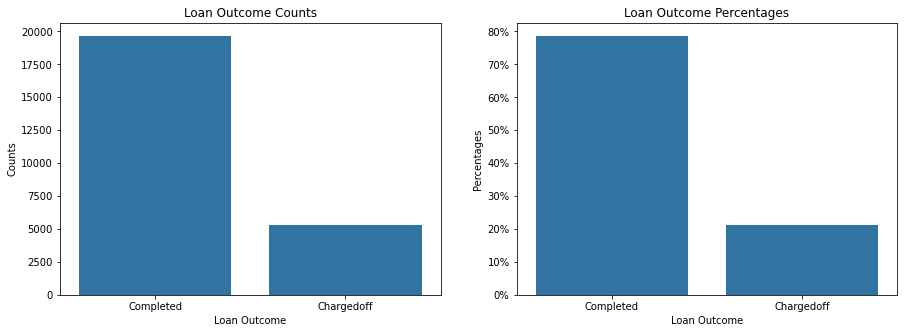

```python
# Plot the counts and percentages for loans that have a final outcome. Either completed of charged off
ax = describe_category(clean_prosper_final, 'LoanStatus', ['Completed', 'Chargedoff'], 1, 2,[15,5])

# Polish the counts plot
ax[0].set_xlabel('Loan Outcome')
ax[0].set_ylabel('Counts')
ax[0].set_title('Loan Outcome Counts')

# Polish the percentage plot
from matplotlib.ticker import PercentFormatter
ax[1].set_xlabel('Loan Outcome')
ax[1].set_ylabel('Percentages')
ax[1].yaxis.set_major_formatter(PercentFormatter(1))
ax[1].set_title('Loan Outcome Percentages')
```

## Prosper Rating vs. Loan Status

Prosper rating is a proprietary system used to assess the estimated loss rates associated with a specific loan. It is based on the borrower's personal information. As we can see below, the percentage of charged-off loans increases with the increase of Prosper rating.

The question that arises is: can Prosper Rating explain all the variation in the count/percentage of charged-off loans or do the other variables have an independent effect on the loan outcome?

To answer this question, I will plot each variable with both the loan outcome and Prosper rating.

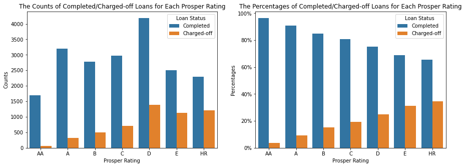

```python
ax = describe_two_categories(clean_prosper_final, 'prosper_rating_alpha', 'LoanStatus', None,
                        ['Completed', 'Chargedoff'], 1, 2, [15, 5], oritentation='v')

# Polish the counts plot
ax[0].set_xlabel('Prosper Rating')
ax[0].set_ylabel('Counts')
ax[0].set_title('The Counts of Completed/Charged-off Loans for Each Prosper Rating')

# Polish the percentage plot
ax[1].set_xlabel('Prosper Rating')
ax[1].set_ylabel('Percentages')
ax[1].yaxis.set_major_formatter(PercentFormatter(1))
ax[1].set_title('The Percentages of Completed/Charged-off Loans for Each Prosper Rating')

# Rename the legend labels
for axes in ax:
    legend = axes.get_legend()
    legend.set_title('Loan Status')
    texts = legend.get_texts()
    texts[1].set_text('Charged-off')
```

## Propser Rating vs. Term vs. Loan Status

The percentage of charged-off loans increases with the increase of Prosper Rating and the increase of the loan term.

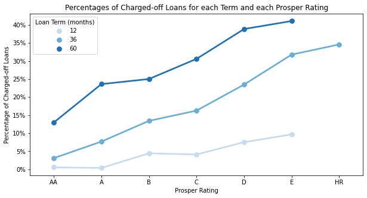

```python
plt.figure(figsize=[10, 5])
ax = sb.pointplot(data = clean_prosper_final, x = 'prosper_rating_alpha', y = 'is_chargedoff'
             , hue = 'Term', palette='Blues', ci = None)

ax.set_xlabel('Prosper Rating')
ax.set_ylabel('Percentage of Charged-off Loans')
ax.yaxis.set_major_formatter(PercentFormatter(1, decimals=0))
ax.set_title('Percentages of Charged-off Loans for each Term and each Prosper Rating')
legend = ax.get_legend()
legend.set_title('Loan Term (months)')
```

## Prosper Rating vs. Listing Category vs. Loan Status

The percentage of charge-off loans increases for each listing category with the increase of Prosper rating. However, the ranking of the categories is different from a prosper rating to another. For example: 'Large Purchases' category had the least percentage of chargeoffs in AA but became the second in E.

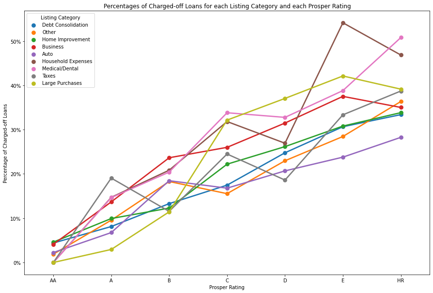

```python
plt.figure(figsize=[15, 10])
order = common_df.listing_category_alpha.value_counts().index
ax = sb.pointplot(data = common_df, x = 'prosper_rating_alpha', y = 'is_chargedoff', hue = 'listing_category_alpha',
             ci = None, palette = "tab10", hue_order=order)

ax.set_xlabel('Prosper Rating')
ax.set_ylabel('Percentage of Charged-off Loans')
ax.yaxis.set_major_formatter(PercentFormatter(1, decimals=0))
ax.set_title('Percentages of Charged-off Loans for each Listing Category and each Prosper Rating')
legend = ax.get_legend()
legend.set_title('Listing Category')
```

## Propser Rating vs. Lender Yield vs. Loan Status

Note : The lender yield is the annual interest that an investor takes.

The distribution of lender yield for both completed and charged-off loans is shifted upwards with the increase of Prosper rating.

From D to HR, the difference between the distribution of lender yield for charged-off and completed loans is weaker. The median lender yield for charged-off loans is still higher but the Q1 is lower than the median lender yield for completed loans.

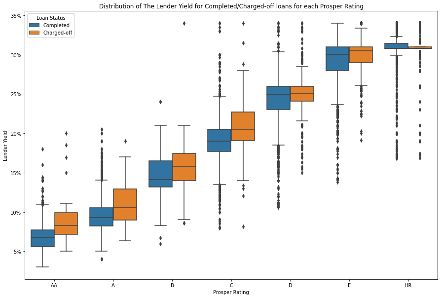

```python
plt.figure(figsize=[15, 10])
ax = sb.boxplot(data = clean_prosper_final, x = 'prosper_rating_alpha', y = 'LenderYield', hue = 'LoanStatus')
ax.set_xlabel('Prosper Rating')
ax.set_ylabel('Lender Yield')
ax.yaxis.set_major_formatter(PercentFormatter(1, decimals=0))
ax.set_title('Distribution of The Lender Yield for Completed/Charged-off loans for each Prosper Rating')
legend = ax.get_legend()
legend.set_title('Loan Status')
texts = legend.get_texts()
texts[1].set_text('Charged-off')
```

## Prosper Rating vs. Loan Original Amount vs. Loan Status

The values of the distribution of the loan amount for both completed and charged-off loans decreased with the increase of Prosper rating. However, the distribution for charged-off loans is higher than the distribution of completed loans within each Prosper rating until HR where they overlap.

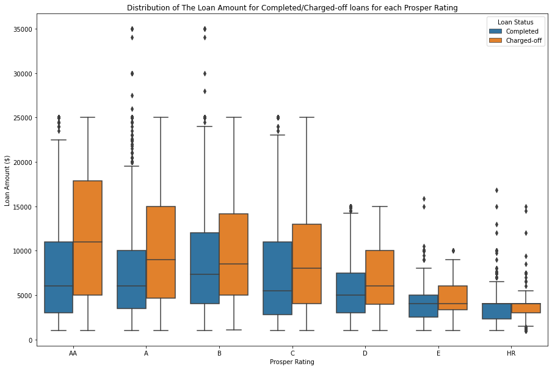

```python
plt.figure(figsize=[15, 10])
ax = sb.boxplot(data = clean_prosper_final, x = 'prosper_rating_alpha', y = 'LoanOriginalAmount', hue = 'LoanStatus')
ax.set_xlabel('Prosper Rating')
ax.set_ylabel('Loan Amount ($)')
ax.set_title('Distribution of The Loan Amount for Completed/Charged-off loans for each Prosper Rating')
legend = ax.get_legend()
legend.set_title('Loan Status')
texts = legend.get_texts()
texts[1].set_text('Charged-off')
```